# All pro DB model

## DATA SCIENCE PORTFOLIO PROJECT 2

Context: The purpose of this model is to see if we can evaluate defenders specifically defensive backs on an objective level from stats to see if we can determine who is an all pro. We want to determine this to decide who is truly the best of the best, this would help a team owner or General manager in real life to determine for example in a contract year how well someone is truly playing and what is their market worth. Do the numbers say you are an all pro or are you just living off of name recognition. Some people may not get the all pro know but still be playing at an all pro level. Theres 32 teams with multiple corners on safeties, however we only get 8-9 all pros per year. This is a classification problem because our model sets out to predict wether a DB is an All pro or not

Data Ethics and Limitations: Corners and Safeties have fairly different jobs and are measured in how good they are in seperate ways. For this exact reason I decided to split my data and models to where we were testing for all pro safeties and all pro corners instead of just all pro DBs. One of the limitations that I ran into which I wouldnt really notice til I was doing my models on my new dataset was that I wasnt able to get any next gen stats for defensive backs, or any of the more important stats for a Corner such as completion percentage against, targets, expected completion percentage against, etc which really hinders my model when predicting an All pro corner. All pro corners may not necessarily have the flashy official stat numbers such as interceptions and tackles because their coverage ability limits targets, for example Christian Gonzales who was a second team all pro in 2024 but didnt necessarily have gaudy numbers, he had only 2 interceptions, with 10 pass deflections, but his ability to cover is what got him the nod which isnt necessarily a stat that you can put a whole number on.

Supporting Research: Ronald Yurko. Quang Nguyen. Konstantinos Pelechrinis. "NFL ghosts: A framework for evaluating defender positioning with conditional density estimation." Ann. Appl. Stat. 20 (1) 873 - 892, March 2026. https://doi.org/10.1214/25-AOAS2132

This study here introduces studying defenders position vs "ghost defenders" which shows that theyre already steps being taken to analyze defenders on a more analytical and quantitative level compared to just interceptions and tackles.

Dartmouth Sports Analytics Lab. (2024, February 13). *Paving the way for the future: A model that determines player value and evaluates trades in the NFL.* Retrieved from https://sites.dartmouth.edu/sportsanalytics/2024/02/13/paving-the-way-for-the-future-a-model-that-determines-player-value-and-evaluates-trades-in-the-nfl/

This article demonstrates how data‑driven models can quantify player value and inform decision‑making in the NFL. It supports the purpose of this project by showing that analytics can objectively evaluate player performance and market worth, the same principle applied here to defensive backs and All‑Pro selection.

Zakarian, C. B. (2026, September 24). *Player Evaluation Metrics.* In *NFL Analytics Textbook.* Retrieved from https://nflanalyticstextbook.com/chapter26

This chapter explains that evaluating players based on reputation or highlight statistics can be misleading because football performance depends on context, teammates, and scheme. It emphasizes the need for quantitative models that isolate individual contributions from team effects, reinforcing the project’s goal of measuring defensive backs by actual performance rather than name recognition.

Code and AI transparency: Minimal Ai used for code refining and helping understand some python issues I was having

```python
import pandas as pd
from sklearn.tree import DecisionTreeClassifier, plot_tree
from sklearn.metrics import classification_report, confusion_matrix, accuracy_score
from sklearn.linear_model import LogisticRegression
import plotly.express as px
import matplotlib.pyplot as plt
import nflreadpy as nfl
import glob
import seaborn as sns
```

```python
seasons: list[str] = [year for year in range(2016, 2026)]
player_stats: pd.DataFrame = nfl.load_player_stats(seasons, summary_level = "reg").to_pandas()
```

```python
player_stats.head(10)
```

|  | player_id | player_name | player_display_name | position | position_group | headshot_url | season | season_type | recent_team | games | ... | pt_out_of_bounds | pt_downed | pt_touchback | pt_fair_caught | pt_returned | pt_return_yards | pt_return_tds | pt_net_yards | fantasy_points | fantasy_points_ppr |
| --- | --- | --- | --- | --- | --- | --- | --- | --- | --- | --- | --- | --- | --- | --- | --- | --- | --- | --- | --- | --- | --- |
| 0 | 00-0004091 | P.Dawson | Phil Dawson | K | SPEC | https://static.www.nfl.com/image/private/f_aut... | 2016 | REG | SF | 16 | ... | 0 | 0 | 0 | 0 | 0 | 0 | 0 | 0 | 0.00 | 0.00 |
| 1 | 00-0016919 | A.Vinatieri | Adam Vinatieri | K | SPEC | https://static.www.nfl.com/image/private/f_aut... | 2016 | REG | IND | 16 | ... | 0 | 0 | 0 | 0 | 0 | 0 | 0 | 0 | 0.00 | 0.00 |
| 2 | 00-0019596 | T.Brady | Tom Brady | QB | QB | https://static.www.nfl.com/image/private/f_aut... | 2016 | REG | NE | 12 | ... | 0 | 0 | 0 | 0 | 0 | 0 | 0 | 0 | 258.56 | 258.56 |
| 3 | 00-0019646 | S.Janikowski | Sebastian Janikowski | K | SPEC | https://static.www.nfl.com/image/private/f_aut... | 2016 | REG | LV | 16 | ... | 0 | 0 | 0 | 0 | 0 | 0 | 0 | 0 | 0.00 | 0.00 |
| 4 | 00-0019714 | S.Lechler | Shane Lechler | P | SPEC | https://static.www.nfl.com/image/private/f_aut... | 2016 | REG | HOU | 16 | ... | 5 | 3 | 3 | 13 | 48 | 477 | 1 | 2886 | 0.00 | 0.00 |
| 5 | 00-0020337 | S.Smith | Steve Smith | WR | WR | https://static.www.nfl.com/image/private/f_aut... | 2016 | REG | BAL | 14 | ... | 0 | 0 | 0 | 0 | 0 | 0 | 0 | 0 | 113.90 | 183.90 |
| 6 | 00-0020531 | D.Brees | Drew Brees | QB | QB | https://static.www.nfl.com/image/private/f_aut... | 2016 | REG | NO | 16 | ... | 0 | 0 | 0 | 0 | 0 | 0 | 0 | 0 | 332.32 | 332.32 |
| 7 | 00-0020578 | M.Bryant | Matt Bryant | K | SPEC | https://static.www.nfl.com/image/private/f_aut... | 2016 | REG | ATL | 16 | ... | 0 | 0 | 0 | 2 | 0 | 0 | 0 | 67 | 0.00 | 0.00 |
| 8 | 00-0020679 | S.Hill | Shaun Hill | QB | QB | https://static.www.nfl.com/image/private/f_aut... | 2016 | REG | MIN | 3 | ... | 0 | 0 | 0 | 0 | 0 | 0 | 0 | 0 | 10.18 | 10.18 |
| 9 | 00-0020712 | J.Harrison | James Harrison | OLB | LB | https://static.www.nfl.com/image/private/f_aut... | 2016 | REG | PIT | 15 | ... | 0 | 0 | 0 | 0 | 0 | 0 | 0 | 0 | 0.00 | 0.00 |

10 rows × 148 columns

```python
for col in player_stats.columns:
    print(col)
```

```
player_id
player_name
player_display_name
position
position_group
headshot_url
season
season_type
recent_team
games
completions
attempts
passing_yards
passing_tds
passing_interceptions
sacks_suffered
sack_yards_lost
sack_fumbles
sack_fumbles_lost
passing_air_yards
passing_yards_after_catch
passing_first_downs
passing_epa
passing_cpoe
passing_2pt_conversions
pacr
passing_10
passing_16
passing_20
passing_40
carries
rushing_yards
rushing_tds
rushing_fumbles
rushing_fumbles_lost
rushing_first_downs
rushing_epa
rushing_2pt_conversions
rushing_10
rushing_12
```

[output cut: 93 more lines]

```
pt_att
pt_blocked
pt_long
pt_yards
pt_inside_20
pt_out_of_bounds
pt_downed
pt_touchback
pt_fair_caught
pt_returned
pt_return_yards
pt_return_tds
pt_net_yards
fantasy_points
fantasy_points_ppr
```

```python
player_stats.loc[
    (player_stats["position_group"] == "DB") & (player_stats["def_tackles_solo"] >= 40)
]
```

|  | player_id | player_name | player_display_name | position | position_group | headshot_url | season | season_type | recent_team | games | ... | pt_out_of_bounds | pt_downed | pt_touchback | pt_fair_caught | pt_returned | pt_return_yards | pt_return_tds | pt_net_yards | fantasy_points | fantasy_points_ppr |
| --- | --- | --- | --- | --- | --- | --- | --- | --- | --- | --- | --- | --- | --- | --- | --- | --- | --- | --- | --- | --- | --- |
| 24 | 00-0022247 | M.Adams | Mike Adams | FS | DB | https://static.www.nfl.com/image/private/f_aut... | 2016 | REG | IND | 14 | ... | 0 | 0 | 0 | 0 | 0 | 0 | 0 | 0 | 0.0 | 0.0 |
| 49 | 00-0023441 | A.Jones | Adam Jones | DB | DB | https://static.www.nfl.com/image/private/f_aut... | 2016 | REG | CIN | 16 | ... | 0 | 0 | 0 | 0 | 0 | 0 | 0 | 0 | 0.0 | 0.0 |
| 74 | 00-0024183 | B.Grimes | Brent Grimes | CB | DB | https://static.www.nfl.com/image/private/f_aut... | 2016 | REG | TB | 16 | ... | 0 | 0 | 0 | 0 | 0 | 0 | 0 | 0 | 0.0 | 0.0 |
| 77 | 00-0024223 | D.Whitner | Donte Whitner | S | DB | https://static.www.nfl.com/image/private/f_aut... | 2016 | REG | WAS | 10 | ... | 0 | 0 | 0 | 0 | 0 | 0 | 0 | 0 | 0.0 | 0.0 |
| 110 | 00-0024421 | A.Bethea | Antoine Bethea | FS | DB | https://static.www.nfl.com/image/private/f_aut... | 2016 | REG | SF | 16 | ... | 0 | 0 | 0 | 0 | 0 | 0 | 0 | 0 | 0.0 | 0.0 |
| ... | ... | ... | ... | ... | ... | ... | ... | ... | ... | ... | ... | ... | ... | ... | ... | ... | ... | ... | ... | ... | ... |
| 19298 | 00-0040165 | M.Moore | Malachi Moore | SAF | DB | https://static.www.nfl.com/image/upload/f_auto... | 2025 | REG | NYJ | 17 | ... | 0 | 0 | 0 | 0 | 0 | 0 | 0 | 0 | 0.3 | 1.3 |
| 19456 | 00-0040643 | J.Sanker | Jonas Sanker | SAF | DB | https://static.www.nfl.com/image/upload/f_auto... | 2025 | REG | NO | 16 | ... | 0 | 0 | 0 | 0 | 0 | 0 | 0 | 0 | 0.0 | 0.0 |
| 19481 | 00-0040688 | M.Starks | Malaki Starks | SAF | DB | https://static.www.nfl.com/image/upload/f_auto... | 2025 | REG | BAL | 17 | ... | 0 | 0 | 0 | 0 | 0 | 0 | 0 | 0 | 0.0 | 0.0 |
| 19493 | 00-0040716 | C.Woodson | Craig Woodson | SAF | DB | https://static.www.nfl.com/image/upload/f_auto... | 2025 | REG | NE | 17 | ... | 0 | 0 | 0 | 0 | 0 | 0 | 0 | 0 | 0.0 | 0.0 |
| 19508 | 00-0040733 | N.Emmanwori | Nick Emmanwori | SAF | DB | https://static.www.nfl.com/image/upload/f_auto... | 2025 | REG | SEA | 14 | ... | 0 | 0 | 0 | 0 | 0 | 0 | 0 | 0 | 0.0 | 0.0 |

948 rows × 148 columns

```python
DB_stats: pd.DataFrame = player_stats.loc[
    player_stats['position_group'] == 'DB'
].reset_index()

print(f"The number of rows in our Player Stats Data: {DB_stats.shape[0]:,}")
print(f"The number of columns in our Census Data: {DB_stats.shape[1]}")
DB_stats.head(5)
```

```
The number of rows in our Player Stats Data: 3,934
The number of columns in our Census Data: 149
```

|  | index | player_id | player_name | player_display_name | position | position_group | headshot_url | season | season_type | recent_team | ... | pt_out_of_bounds | pt_downed | pt_touchback | pt_fair_caught | pt_returned | pt_return_yards | pt_return_tds | pt_net_yards | fantasy_points | fantasy_points_ppr |
| --- | --- | --- | --- | --- | --- | --- | --- | --- | --- | --- | --- | --- | --- | --- | --- | --- | --- | --- | --- | --- | --- |
| 0 | 19 | 00-0022045 | T.Newman | Terence Newman | CB | DB | https://static.www.nfl.com/image/private/f_aut... | 2016 | REG | MIN | ... | 0 | 0 | 0 | 0 | 0 | 0 | 0 | 0 | 0.0 | 0.0 |
| 1 | 24 | 00-0022247 | M.Adams | Mike Adams | FS | DB | https://static.www.nfl.com/image/private/f_aut... | 2016 | REG | IND | ... | 0 | 0 | 0 | 0 | 0 | 0 | 0 | 0 | 0.0 | 0.0 |
| 2 | 35 | 00-0022923 | D.Hall | DeAngelo Hall | S | DB | https://static.www.nfl.com/image/private/f_aut... | 2016 | REG | WAS | ... | 0 | 0 | 0 | 0 | 0 | 0 | 0 | 0 | 0.0 | 0.0 |
| 3 | 49 | 00-0023441 | A.Jones | Adam Jones | DB | DB | https://static.www.nfl.com/image/private/f_aut... | 2016 | REG | CIN | ... | 0 | 0 | 0 | 0 | 0 | 0 | 0 | 0 | 0.0 | 0.0 |
| 4 | 72 | 00-0024061 | T.Williams Sr. | Tramon Williams | CB | DB | https://static.www.nfl.com/image/private/f_aut... | 2016 | REG | CLE | ... | 0 | 0 | 0 | 0 | 0 | 0 | 0 | 0 | 0.0 | 0.0 |

5 rows × 149 columns

```python
"""
    "player_id",
    "season",
    "player_display_name",
    "def_tackles_solo",
"def_tackles_with_assist",
"def_tackle_assists",
"def_tackles_for_loss",
"def_tackles_for_loss_yards",
"def_fumbles_forced",
"def_sacks",
"def_sack_yards",
"def_qb_hits",
"def_interceptions",
"def_interception_yards",
"def_pass_defended",
"def_tds",
"def_fumbles",
"def_safeties",
"def_punt_blocks",
"def_pat_blocks",
"def_fg_blocks",
"fumble_recovery_tds",
"penalties",
"penalty_yards",
"position",
"position_group"
"""
DB_stats: pd.DataFrame = DB_stats[["player_id",
"season",
"player_display_name",
"def_tackles_solo",
"def_tackles_with_assist",
"def_tackle_assists",
"def_tackles_for_loss",
"def_tackles_for_loss_yards",
"def_fumbles_forced",
'def_sacks',
"def_sack_yards",
"def_qb_hits",
"def_interceptions",
"def_pass_defended",
"def_tds",
"def_fumbles",
"def_safeties",
"def_punt_blocks",
"def_fg_blocks",
"fumble_recovery_tds",
"penalties",
"penalty_yards",
"position",
"position_group"

   ,]]


DB_stats.head(5)
```

|  | player_id | season | player_display_name | def_tackles_solo | def_tackles_with_assist | def_tackle_assists | def_tackles_for_loss | def_tackles_for_loss_yards | def_fumbles_forced | def_sacks | ... | def_tds | def_fumbles | def_safeties | def_punt_blocks | def_fg_blocks | fumble_recovery_tds | penalties | penalty_yards | position | position_group |
| --- | --- | --- | --- | --- | --- | --- | --- | --- | --- | --- | --- | --- | --- | --- | --- | --- | --- | --- | --- | --- | --- |
| 0 | 00-0022045 | 2016 | Terence Newman | 33 | 0 | 5 | 3 | 7 | 0 | 0.0 | ... | 0 | 0 | 0 | 0 | 0 | 0 | 4 | 51 | CB | DB |
| 1 | 00-0022247 | 2016 | Mike Adams | 60 | 2 | 17 | 1 | 1 | 2 | 0.0 | ... | 0 | 0 | 0 | 0 | 0 | 0 | 0 | 0 | FS | DB |
| 2 | 00-0022923 | 2016 | DeAngelo Hall | 9 | 1 | 6 | 0 | 0 | 0 | 0.0 | ... | 0 | 0 | 0 | 0 | 0 | 0 | 0 | 0 | S | DB |
| 3 | 00-0023441 | 2016 | Adam Jones | 53 | 1 | 12 | 0 | 0 | 1 | 0.0 | ... | 0 | 3 | 0 | 0 | 0 | 0 | 7 | 52 | DB | DB |
| 4 | 00-0024061 | 2016 | Tramon Williams | 28 | 0 | 8 | 1 | 1 | 0 | 0.0 | ... | 0 | 1 | 0 | 0 | 0 | 0 | 2 | 10 | CB | DB |

5 rows × 24 columns

```python
print(DB_stats)
```

```
       player_id  season player_display_name  def_tackles_solo  \
0     00-0022045    2016      Terence Newman                33
1     00-0022247    2016          Mike Adams                60
2     00-0022923    2016       DeAngelo Hall                 9
3     00-0023441    2016          Adam Jones                53
4     00-0024061    2016     Tramon Williams                28
...          ...     ...                 ...               ...
3929  00-0040731    2025           Trey Amos                18
3930  00-0040733    2025      Nick Emmanwori                55
3931  00-0040747    2025   Benjamin Morrison                18
3932  00-0040749    2025       Andrew Mukuba                24
3933  00-0040751    2025        Will Johnson                24

      def_tackles_with_assist  def_tackle_assists  def_tackles_for_loss  \
0                           0                   5                     3
```

[output cut: 51 more lines]

```python
AP2021=pd.read_csv(r"C:\Users\Admin\Downloads\all-pro-players-2021.csv",sep=None, engine="python")
AP2022=pd.read_csv(r"C:\Users\Admin\Downloads\all-pro-players-2022.csv",sep=None, engine="python")
AP2023=pd.read_csv(r"C:\Users\Admin\Downloads\all-pro-players-2023.csv",sep=None, engine="python")
AP2024=pd.read_csv(r"C:\Users\Admin\Downloads\all-pro-players-2024.csv",sep=None, engine="python")
AP2025=pd.read_csv(r"C:\Users\Admin\Downloads\all-pro-players-2025.csv",sep=None, engine="python")


print(AP2021.columns)
print(AP2021.head())
```

```
Index(['Pos', 'Player', 'Tm', 'Age', 'Yrs', 'G', 'GS', 'Cmp', 'Att', 'Yds',
       'TD', 'Int', 'Att.1', 'Yds.1', 'TD.1', 'Rec', 'Yds.2', 'TD.2', 'Solo',
       'Sk', 'Int.1', 'All-pro teams', 'Player-additional', 'Year'],
      dtype='object')
  Pos           Player   Tm  Age Yrs   G  GS  Cmp  Att   Yds  ...  TD.1  Rec  \
0   QB    Aaron Rodgers  GNB   38  16  16  16  366  531  4115  ...     3    1
1   QB        Tom Brady  TAM   44  21  17  17  485  719  5316  ...     2    0
2   QB       Joe Burrow  CIN   25   1  16  16  366  520  4611  ...     2    0
3   RB  Jonathan Taylor  IND   22   1  17  17    0    0     0  ...    18   40
4   RB       Nick Chubb  CLE   26   3  14  14    0    0     0  ...     8   20

   Yds.2  TD.2  Solo   Sk  Int.1  \
0     -4     0     0  0.0      0
1      0     0     0  0.0      0
2      0     0     1  0.0      0
3    360     2     0  0.0      0
4    174     1     0  0.0      0

                                       All-pro teams  Player-additional  Year
0  FW: 1st Tm All-Conf. AP: 1st Tm FW: 1st Tm SN:...           RodgAa00  2021
1                             AP: 2nd Tm PFF: 1st Tm           BradTo00  2021
2                   FW: 1st Tm All-Conf. PFF: 2nd Tm           BurrJo01  2021
3  FW: 1st Tm All-Conf. AP: 1st Tm FW: 1st Tm PFF...           TaylJo02  2021
4                    FW: 1st Tm All-Conf. FW: 1st Tm           ChubNi00  2021

[5 rows x 24 columns]
```

```python
print(AP2021.shape, AP2022.shape, AP2023.shape, AP2024.shape, AP2025.shape)
```

```
(87, 24) (91, 24) (97, 24) (90, 24) (97, 24)
```

```python
all_pro_players = pd.concat([AP2021, AP2022, AP2023, AP2024, AP2025], ignore_index=True)
print(all_pro_players.shape)
display(all_pro_players.head())
```

```
(462, 24)
```

|  | Pos | Player | Tm | Age | Yrs | G | GS | Cmp | Att | Yds | ... | TD.1 | Rec | Yds.2 | TD.2 | Solo | Sk | Int.1 | All-pro teams | Player-additional | Year |
| --- | --- | --- | --- | --- | --- | --- | --- | --- | --- | --- | --- | --- | --- | --- | --- | --- | --- | --- | --- | --- | --- |
| 0 | QB | Aaron Rodgers | GNB | 38 | 16 | 16 | 16 | 366 | 531 | 4115 | ... | 3 | 1 | -4 | 0 | 0 | 0.0 | 0 | FW: 1st Tm All-Conf. AP: 1st Tm FW: 1st Tm SN:... | RodgAa00 | 2021 |
| 1 | QB | Tom Brady | TAM | 44 | 21 | 17 | 17 | 485 | 719 | 5316 | ... | 2 | 0 | 0 | 0 | 0 | 0.0 | 0 | AP: 2nd Tm PFF: 1st Tm | BradTo00 | 2021 |
| 2 | QB | Joe Burrow | CIN | 25 | 1 | 16 | 16 | 366 | 520 | 4611 | ... | 2 | 0 | 0 | 0 | 1 | 0.0 | 0 | FW: 1st Tm All-Conf. PFF: 2nd Tm | BurrJo01 | 2021 |
| 3 | RB | Jonathan Taylor | IND | 22 | 1 | 17 | 17 | 0 | 0 | 0 | ... | 18 | 40 | 360 | 2 | 0 | 0.0 | 0 | FW: 1st Tm All-Conf. AP: 1st Tm FW: 1st Tm PFF... | TaylJo02 | 2021 |
| 4 | RB | Nick Chubb | CLE | 26 | 3 | 14 | 14 | 0 | 0 | 0 | ... | 8 | 20 | 174 | 1 | 0 | 0.0 | 0 | FW: 1st Tm All-Conf. FW: 1st Tm | ChubNi00 | 2021 |

5 rows × 24 columns

```python
all_pro_players.columns = all_pro_players.columns.str.strip()
all_pro_players.columns = all_pro_players.columns.str.title()


all_pro_dbs = all_pro_players.loc[
    all_pro_players["\ufeffPos"].isin(["CB", "S", "DB"])
].reset_index()

display(all_pro_dbs.head())
print(all_pro_dbs.shape)
```

|  | index | Pos | Player | Tm | Age | Yrs | G | Gs | Cmp | Att | ... | Td.1 | Rec | Yds.2 | Td.2 | Solo | Sk | Int.1 | All-Pro Teams | Player-Additional | Year |
| --- | --- | --- | --- | --- | --- | --- | --- | --- | --- | --- | --- | --- | --- | --- | --- | --- | --- | --- | --- | --- | --- |
| 0 | 52 | CB | Jalen Ramsey | LAR | 27 | 5 | 16 | 16 | 0 | 0 | ... | 0 | 0 | 0 | 0 | 62 | 0.0 | 4 | FW: 1st Tm All-Conf. AP: 1st Tm FW: 1st Tm PFF... | RamsJa00 | 2021 |
| 1 | 53 | CB | Trevon Diggs | DAL | 23 | 1 | 16 | 16 | 0 | 0 | ... | 0 | 0 | 0 | 0 | 43 | 0.0 | 11 | FW: 1st Tm All-Conf. AP: 1st Tm FW: 1st Tm SN:... | DiggTr00 | 2021 |
| 2 | 54 | CB | AJ Terrell | ATL | 23 | 1 | 16 | 16 | 0 | 0 | ... | 0 | 0 | 0 | 0 | 52 | 1.0 | 3 | PFF: 1st Tm AP: 2nd Tm | TerrAJ00 | 2021 |
| 3 | 55 | CB | J.C. Jackson | NWE | 26 | 3 | 17 | 17 | 0 | 0 | ... | 0 | 0 | 0 | 0 | 44 | 0.0 | 8 | FW: 1st Tm All-Conf. AP: 2nd Tm | JackJ.00 | 2021 |
| 4 | 56 | CB | Xavien Howard | MIA | 28 | 5 | 16 | 16 | 0 | 0 | ... | 0 | 0 | 0 | 0 | 39 | 1.0 | 5 | FW: 1st Tm All-Conf. | HowaXa00 | 2021 |

5 rows × 25 columns

```
(80, 25)
```

```python
all_pro_dbs.head(20)
```

|  | index | Pos | Player | Tm | Age | Yrs | G | Gs | Cmp | Att | ... | Td.1 | Rec | Yds.2 | Td.2 | Solo | Sk | Int.1 | All-Pro Teams | Player-Additional | Year |
| --- | --- | --- | --- | --- | --- | --- | --- | --- | --- | --- | --- | --- | --- | --- | --- | --- | --- | --- | --- | --- | --- |
| 0 | 52 | CB | Jalen Ramsey | LAR | 27 | 5 | 16 | 16 | 0 | 0 | ... | 0 | 0 | 0 | 0 | 62 | 0.0 | 4 | FW: 1st Tm All-Conf. AP: 1st Tm FW: 1st Tm PFF... | RamsJa00 | 2021 |
| 1 | 53 | CB | Trevon Diggs | DAL | 23 | 1 | 16 | 16 | 0 | 0 | ... | 0 | 0 | 0 | 0 | 43 | 0.0 | 11 | FW: 1st Tm All-Conf. AP: 1st Tm FW: 1st Tm SN:... | DiggTr00 | 2021 |
| 2 | 54 | CB | AJ Terrell | ATL | 23 | 1 | 16 | 16 | 0 | 0 | ... | 0 | 0 | 0 | 0 | 52 | 1.0 | 3 | PFF: 1st Tm AP: 2nd Tm | TerrAJ00 | 2021 |
| 3 | 55 | CB | J.C. Jackson | NWE | 26 | 3 | 17 | 17 | 0 | 0 | ... | 0 | 0 | 0 | 0 | 44 | 0.0 | 8 | FW: 1st Tm All-Conf. AP: 2nd Tm | JackJ.00 | 2021 |
| 4 | 56 | CB | Xavien Howard | MIA | 28 | 5 | 16 | 16 | 0 | 0 | ... | 0 | 0 | 0 | 0 | 39 | 1.0 | 5 | FW: 1st Tm All-Conf. | HowaXa00 | 2021 |
| 5 | 57 | CB | Chidobe Awuzie | CIN | 26 | 4 | 14 | 14 | 0 | 0 | ... | 0 | 0 | 0 | 0 | 53 | 0.0 | 2 | PFF: 2nd Tm | AwuzCh00 | 2021 |
| 6 | 58 | CB | Darius Slay | PHI | 30 | 8 | 16 | 16 | 0 | 0 | ... | 0 | 0 | 0 | 0 | 40 | 0.0 | 3 | PFF: 2nd Tm | SlayDa00 | 2021 |
| 7 | 59 | S | Kevin Byard | TEN | 28 | 5 | 17 | 17 | 0 | 0 | ... | 0 | 0 | 0 | 0 | 57 | 1.0 | 5 | FW: 1st Tm All-Conf. AP: 1st Tm FW: 1st Tm PFF... | ByarKe01 | 2021 |
| 8 | 60 | S | Jordan Poyer | BUF | 30 | 8 | 16 | 16 | 0 | 0 | ... | 0 | 0 | 0 | 0 | 66 | 3.0 | 5 | FW: 1st Tm All-Conf. AP: 1st Tm FW: 1st Tm | PoyeJo00 | 2021 |
| 9 | 61 | S | Derwin James | LAC | 25 | 3 | 15 | 15 | 0 | 0 | ... | 0 | 0 | 0 | 0 | 75 | 2.0 | 2 | SN: 1st Tm | JameDe00 | 2021 |
| 10 | 62 | S | Antoine Winfield Jr. | TAM | 23 | 1 | 13 | 13 | 0 | 0 | ... | 0 | 0 | 0 | 0 | 62 | 2.0 | 2 | PFF: 1st Tm | WinfAn00 | 2021 |
| 11 | 63 | S | Budda Baker | ARI | 25 | 4 | 17 | 17 | 0 | 0 | ... | 0 | 0 | 0 | 0 | 63 | 2.0 | 3 | FW: 1st Tm All-Conf. AP: 2nd Tm | BakeBu00 | 2021 |
| 12 | 64 | S | Quandre Diggs | SEA | 28 | 6 | 17 | 17 | 0 | 0 | ... | 0 | 0 | 0 | 0 | 66 | 0.0 | 5 | FW: 1st Tm All-Conf. | DiggQu00 | 2021 |
| 13 | 65 | S | Micah Hyde | BUF | 31 | 8 | 17 | 17 | 0 | 0 | ... | 0 | 0 | 0 | 0 | 53 | 1.0 | 5 | AP: 2nd Tm PFF: 2nd Tm | HydeMi00 | 2021 |
| 14 | 66 | S | Marcus Williams | NOR | 25 | 4 | 16 | 16 | 0 | 0 | ... | 0 | 0 | 0 | 0 | 52 | 0.0 | 2 | PFF: 2nd Tm | WillMa06 | 2021 |
| 15 | 67 | S | Justin Simmons | DEN | 28 | 5 | 17 | 17 | 0 | 0 | ... | 0 | 0 | 0 | 0 | 60 | 1.5 | 5 | AP: 2nd Tm | SimmJu00 | 2021 |
| 16 | 142 | CB | Patrick Surtain II | DEN | 22 | 1 | 17 | 17 | 0 | 0 | ... | 0 | 0 | 0 | 0 | 46 | 0.0 | 2 | FW: 1st Tm All-Conf. AP: 1st Tm FW: 1st Tm NFL... | SurtPa01 | 2022 |
| 17 | 143 | CB | Sauce Gardner | NYJ | 21 | Rook | 17 | 17 | 0 | 0 | ... | 0 | 0 | 0 | 0 | 51 | 0.0 | 2 | FW: 1st Tm All-Conf. AP: 1st Tm FW: 1st Tm PFF... | GardSa00 | 2022 |
| 18 | 144 | CB | Darius Slay | PHI | 31 | 9 | 17 | 17 | 0 | 0 | ... | 0 | 0 | 0 | 0 | 40 | 0.0 | 3 | FW: 1st Tm All-Conf. NFLPA: 1st Tm | SlayDa00 | 2022 |
| 19 | 145 | CB | Jaire Alexander | GNB | 25 | 4 | 16 | 16 | 0 | 0 | ... | 0 | 0 | 0 | 0 | 43 | 0.0 | 5 | FW: 1st Tm All-Conf. AP: 2nd Tm PFF: 2nd Tm | AlexJa00 | 2022 |

20 rows × 25 columns

```python
for col in all_pro_players.columns:
    print(repr(col))
```

```
'\ufeffPos'
'Player'
'Tm'
'Age'
'Yrs'
'G'
'Gs'
'Cmp'
'Att'
'Yds'
'Td'
'Int'
'Att.1'
'Yds.1'
'Td.1'
'Rec'
'Yds.2'
'Td.2'
'Solo'
'Sk'
'Int.1'
'All-Pro Teams'
'Player-Additional'
'Year'
```

```python
print(all_pro_dbs.columns)
```

```
Index(['index', 'Pos', 'Player', 'Tm', 'Age', 'Yrs', 'G', 'Gs', 'Cmp', 'Att',
       'Yds', 'Td', 'Int', 'Att.1', 'Yds.1', 'Td.1', 'Rec', 'Yds.2', 'Td.2',
       'Solo', 'Sk', 'Int.1', 'All-Pro Teams', 'Player-Additional', 'Year'],
      dtype='object')
```

```python
all_pro_dbs['is_ap_in_column'] = all_pro_dbs['All-Pro Teams'].str.contains('AP:')

all_pro_dbs
```

|  | index | Pos | Player | Tm | Age | Yrs | G | Gs | Cmp | Att | ... | Rec | Yds.2 | Td.2 | Solo | Sk | Int.1 | All-Pro Teams | Player-Additional | Year | is_ap_in_column |
| --- | --- | --- | --- | --- | --- | --- | --- | --- | --- | --- | --- | --- | --- | --- | --- | --- | --- | --- | --- | --- | --- |
| 0 | 52 | CB | Jalen Ramsey | LAR | 27 | 5 | 16 | 16 | 0 | 0 | ... | 0 | 0 | 0 | 62 | 0.0 | 4 | FW: 1st Tm All-Conf. AP: 1st Tm FW: 1st Tm PFF... | RamsJa00 | 2021 | True |
| 1 | 53 | CB | Trevon Diggs | DAL | 23 | 1 | 16 | 16 | 0 | 0 | ... | 0 | 0 | 0 | 43 | 0.0 | 11 | FW: 1st Tm All-Conf. AP: 1st Tm FW: 1st Tm SN:... | DiggTr00 | 2021 | True |
| 2 | 54 | CB | AJ Terrell | ATL | 23 | 1 | 16 | 16 | 0 | 0 | ... | 0 | 0 | 0 | 52 | 1.0 | 3 | PFF: 1st Tm AP: 2nd Tm | TerrAJ00 | 2021 | True |
| 3 | 55 | CB | J.C. Jackson | NWE | 26 | 3 | 17 | 17 | 0 | 0 | ... | 0 | 0 | 0 | 44 | 0.0 | 8 | FW: 1st Tm All-Conf. AP: 2nd Tm | JackJ.00 | 2021 | True |
| 4 | 56 | CB | Xavien Howard | MIA | 28 | 5 | 16 | 16 | 0 | 0 | ... | 0 | 0 | 0 | 39 | 1.0 | 5 | FW: 1st Tm All-Conf. | HowaXa00 | 2021 | False |
| ... | ... | ... | ... | ... | ... | ... | ... | ... | ... | ... | ... | ... | ... | ... | ... | ... | ... | ... | ... | ... | ... |
| 75 | 434 | S | Xavier Watts | ATL | 24 | Rook | 17 | 17 | 0 | 0 | ... | 0 | 0 | 0 | 59 | 0.0 | 5 | FW: 1st Tm All-Conf. | WattXa00 | 2025 | False |
| 76 | 435 | S | Xavier McKinney | GNB | 27 | 5 | 16 | 16 | 0 | 0 | ... | 0 | 0 | 0 | 54 | 1.0 | 2 | AP: 2nd Tm | McKiXa00 | 2025 | True |
| 77 | 436 | S | Talanoa Hufanga | DEN | 26 | 4 | 17 | 17 | 0 | 0 | ... | 0 | 0 | 0 | 67 | 2.0 | 0 | AP: 2nd Tm | HufaTa00 | 2025 | True |
| 78 | 437 | S | Jessie Bates III | ATL | 28 | 7 | 17 | 17 | 0 | 0 | ... | 0 | 0 | 0 | 57 | 0.0 | 3 | AP: 2nd Tm | BateJe00 | 2025 | True |
| 79 | 438 | S | Antonio Johnson | JAX | 24 | 2 | 17 | 9 | 0 | 0 | ... | 0 | 0 | 0 | 37 | 2.0 | 5 | PFF: 2nd Tm | JohnAn07 | 2025 | False |

80 rows × 26 columns

```python
all_pro_dbs['ap_designation'] = all_pro_dbs['All-Pro Teams'].str.extract(r'AP: (.{6})')

all_pro_dbs.head(10)
```

|  | index | Pos | Player | Tm | Age | Yrs | G | Gs | Cmp | Att | ... | Yds.2 | Td.2 | Solo | Sk | Int.1 | All-Pro Teams | Player-Additional | Year | is_ap_in_column | ap_designation |
| --- | --- | --- | --- | --- | --- | --- | --- | --- | --- | --- | --- | --- | --- | --- | --- | --- | --- | --- | --- | --- | --- |
| 0 | 52 | CB | Jalen Ramsey | LAR | 27 | 5 | 16 | 16 | 0 | 0 | ... | 0 | 0 | 62 | 0.0 | 4 | FW: 1st Tm All-Conf. AP: 1st Tm FW: 1st Tm PFF... | RamsJa00 | 2021 | True | 1st Tm |
| 1 | 53 | CB | Trevon Diggs | DAL | 23 | 1 | 16 | 16 | 0 | 0 | ... | 0 | 0 | 43 | 0.0 | 11 | FW: 1st Tm All-Conf. AP: 1st Tm FW: 1st Tm SN:... | DiggTr00 | 2021 | True | 1st Tm |
| 2 | 54 | CB | AJ Terrell | ATL | 23 | 1 | 16 | 16 | 0 | 0 | ... | 0 | 0 | 52 | 1.0 | 3 | PFF: 1st Tm AP: 2nd Tm | TerrAJ00 | 2021 | True | 2nd Tm |
| 3 | 55 | CB | J.C. Jackson | NWE | 26 | 3 | 17 | 17 | 0 | 0 | ... | 0 | 0 | 44 | 0.0 | 8 | FW: 1st Tm All-Conf. AP: 2nd Tm | JackJ.00 | 2021 | True | 2nd Tm |
| 4 | 56 | CB | Xavien Howard | MIA | 28 | 5 | 16 | 16 | 0 | 0 | ... | 0 | 0 | 39 | 1.0 | 5 | FW: 1st Tm All-Conf. | HowaXa00 | 2021 | False | NaN |
| 5 | 57 | CB | Chidobe Awuzie | CIN | 26 | 4 | 14 | 14 | 0 | 0 | ... | 0 | 0 | 53 | 0.0 | 2 | PFF: 2nd Tm | AwuzCh00 | 2021 | False | NaN |
| 6 | 58 | CB | Darius Slay | PHI | 30 | 8 | 16 | 16 | 0 | 0 | ... | 0 | 0 | 40 | 0.0 | 3 | PFF: 2nd Tm | SlayDa00 | 2021 | False | NaN |
| 7 | 59 | S | Kevin Byard | TEN | 28 | 5 | 17 | 17 | 0 | 0 | ... | 0 | 0 | 57 | 1.0 | 5 | FW: 1st Tm All-Conf. AP: 1st Tm FW: 1st Tm PFF... | ByarKe01 | 2021 | True | 1st Tm |
| 8 | 60 | S | Jordan Poyer | BUF | 30 | 8 | 16 | 16 | 0 | 0 | ... | 0 | 0 | 66 | 3.0 | 5 | FW: 1st Tm All-Conf. AP: 1st Tm FW: 1st Tm | PoyeJo00 | 2021 | True | 1st Tm |
| 9 | 61 | S | Derwin James | LAC | 25 | 3 | 15 | 15 | 0 | 0 | ... | 0 | 0 | 75 | 2.0 | 2 | SN: 1st Tm | JameDe00 | 2021 | False | NaN |

10 rows × 27 columns

```python
print(f"We currently have {len(all_pro_dbs)} DBS in our dataset")
all_pro_dbs_ap = all_pro_dbs.loc[
    all_pro_dbs["ap_designation"].notna()
][["Player", "Year", "ap_designation","\ufeffPos"]]
display(all_pro_dbs_ap.head(10))
print(f"We currently have {len(all_pro_dbs_ap)} DBS in our dataset")
```

```
We currently have 80 DBS in our dataset
```

|  | Player | Year | ap_designation | Pos |
| --- | --- | --- | --- | --- |
| 0 | Jalen Ramsey | 2021 | 1st Tm | CB |
| 1 | Trevon Diggs | 2021 | 1st Tm | CB |
| 2 | AJ Terrell | 2021 | 2nd Tm | CB |
| 3 | J.C. Jackson | 2021 | 2nd Tm | CB |
| 7 | Kevin Byard | 2021 | 1st Tm | S |
| 8 | Jordan Poyer | 2021 | 1st Tm | S |
| 11 | Budda Baker | 2021 | 2nd Tm | S |
| 13 | Micah Hyde | 2021 | 2nd Tm | S |
| 15 | Justin Simmons | 2021 | 2nd Tm | S |
| 16 | Patrick Surtain II | 2022 | 1st Tm | CB |

```
We currently have 48 DBS in our dataset
```

```python
DB_stats["player_display_name"] = DB_stats["player_display_name"].str.strip().str.lower()
all_pro_dbs_ap["Player"] = all_pro_dbs["Player"].str.strip().str.lower()

DB_stats["season"] = DB_stats["season"].astype(int)
all_pro_dbs_ap["Year"] = all_pro_dbs["Year"].astype(int)





all_pro_dbs_ap = all_pro_dbs_ap[["Player", "ap_designation", "Year", "\ufeffPos"]]
display(all_pro_dbs_ap.head(15))
```

|  | Player | ap_designation | Year | Pos |
| --- | --- | --- | --- | --- |
| 0 | jalen ramsey | 1st Tm | 2021 | CB |
| 1 | trevon diggs | 1st Tm | 2021 | CB |
| 2 | aj terrell | 2nd Tm | 2021 | CB |
| 3 | j.c. jackson | 2nd Tm | 2021 | CB |
| 7 | kevin byard | 1st Tm | 2021 | S |
| 8 | jordan poyer | 1st Tm | 2021 | S |
| 11 | budda baker | 2nd Tm | 2021 | S |
| 13 | micah hyde | 2nd Tm | 2021 | S |
| 15 | justin simmons | 2nd Tm | 2021 | S |
| 16 | patrick surtain ii | 1st Tm | 2022 | CB |
| 17 | sauce gardner | 1st Tm | 2022 | CB |
| 19 | jaire alexander | 2nd Tm | 2022 | CB |
| 20 | james bradberry | 2nd Tm | 2022 | CB |
| 23 | minkah fitzpatrick | 1st Tm | 2022 | S |
| 24 | derwin james | 2nd Tm | 2022 | S |

```python
DB_stats.columns = DB_stats.columns.str.replace("\ufeff", "")
all_pro_dbs_ap.columns = all_pro_dbs_ap.columns.str.replace("\ufeff", "")


DB_stats["player_display_name"] = DB_stats["player_display_name"].str.strip().str.lower()
all_pro_dbs_ap["Player"] = all_pro_dbs_ap["Player"].str.strip().str.lower()

DB_stats["season"] = DB_stats["season"].astype(int)
all_pro_dbs_ap["Year"] = all_pro_dbs_ap["Year"].astype(int)


all_pro_dbs_ap = all_pro_dbs_ap.rename(columns={
    "Player": "player_display_name",
    "Year": "season"
})


db_combined = DB_stats.merge(
    all_pro_dbs_ap,
    on=["player_display_name", "season"],
    how="left"
)


display(db_combined.head())
print(db_combined.columns)
print(db_combined["Pos"].value_counts(dropna=False))
```

|  | player_id | season | player_display_name | def_tackles_solo | def_tackles_with_assist | def_tackle_assists | def_tackles_for_loss | def_tackles_for_loss_yards | def_fumbles_forced | def_sacks | ... | def_safeties | def_punt_blocks | def_fg_blocks | fumble_recovery_tds | penalties | penalty_yards | position | position_group | ap_designation | Pos |
| --- | --- | --- | --- | --- | --- | --- | --- | --- | --- | --- | --- | --- | --- | --- | --- | --- | --- | --- | --- | --- | --- |
| 0 | 00-0022045 | 2016 | terence newman | 33 | 0 | 5 | 3 | 7 | 0 | 0.0 | ... | 0 | 0 | 0 | 0 | 4 | 51 | CB | DB | NaN | NaN |
| 1 | 00-0022247 | 2016 | mike adams | 60 | 2 | 17 | 1 | 1 | 2 | 0.0 | ... | 0 | 0 | 0 | 0 | 0 | 0 | FS | DB | NaN | NaN |
| 2 | 00-0022923 | 2016 | deangelo hall | 9 | 1 | 6 | 0 | 0 | 0 | 0.0 | ... | 0 | 0 | 0 | 0 | 0 | 0 | S | DB | NaN | NaN |
| 3 | 00-0023441 | 2016 | adam jones | 53 | 1 | 12 | 0 | 0 | 1 | 0.0 | ... | 0 | 0 | 0 | 0 | 7 | 52 | DB | DB | NaN | NaN |
| 4 | 00-0024061 | 2016 | tramon williams | 28 | 0 | 8 | 1 | 1 | 0 | 0.0 | ... | 0 | 0 | 0 | 0 | 2 | 10 | CB | DB | NaN | NaN |

5 rows × 26 columns

```
Index(['player_id', 'season', 'player_display_name', 'def_tackles_solo',
       'def_tackles_with_assist', 'def_tackle_assists', 'def_tackles_for_loss',
       'def_tackles_for_loss_yards', 'def_fumbles_forced', 'def_sacks',
       'def_sack_yards', 'def_qb_hits', 'def_interceptions',
       'def_pass_defended', 'def_tds', 'def_fumbles', 'def_safeties',
       'def_punt_blocks', 'def_fg_blocks', 'fumble_recovery_tds', 'penalties',
       'penalty_yards', 'position', 'position_group', 'ap_designation', 'Pos'],
      dtype='object')
Pos
NaN    3892
S        22
CB       20
Name: count, dtype: int64
```

```python
print(db_combined[["position", "Pos"]].head())
```

```
  position  Pos
0       CB  NaN
1       FS  NaN
2        S  NaN
3       DB  NaN
4       CB  NaN
```

```python
db_combined = db_combined.drop(columns=["Pos"])
```

```python
db_combined.describe()
```

|  | season | def_tackles_solo | def_tackles_with_assist | def_tackle_assists | def_tackles_for_loss | def_tackles_for_loss_yards | def_fumbles_forced | def_sacks | def_sack_yards | def_qb_hits | def_interceptions | def_pass_defended | def_tds | def_fumbles | def_safeties | def_punt_blocks | def_fg_blocks | fumble_recovery_tds | penalties | penalty_yards |
| --- | --- | --- | --- | --- | --- | --- | --- | --- | --- | --- | --- | --- | --- | --- | --- | --- | --- | --- | --- | --- |
| count | 3934.000000 | 3934.000000 | 3934.000000 | 3934.000000 | 3934.000000 | 3934.000000 | 3934.000000 | 3934.000000 | 3934.000000 | 3934.000000 | 3934.000000 | 3934.000000 | 3934.000000 | 3934.000000 | 3934.000000 | 3934.000000 | 3934.000000 | 3934.000000 | 3934.000000 | 3934.000000 |
| mean | 2020.618454 | 24.059481 | 1.992628 | 9.733350 | 1.023132 | 3.486019 | 0.343162 | 0.245552 | 1.704753 | 0.551347 | 0.821556 | 3.943060 | 0.065074 | 0.041942 | 0.004067 | 0.006609 | 0.008643 | 0.020590 | 1.942552 | 21.070920 |
| std | 2.855459 | 19.459216 | 2.657535 | 9.800804 | 1.564520 | 6.337903 | 0.691882 | 0.612149 | 4.731443 | 1.149971 | 1.280884 | 4.312696 | 0.274957 | 0.259123 | 0.063652 | 0.087087 | 0.095282 | 0.152388 | 2.087156 | 25.471058 |
| min | 2016.000000 | 0.000000 | 0.000000 | 0.000000 | 0.000000 | 0.000000 | 0.000000 | 0.000000 | 0.000000 | 0.000000 | 0.000000 | 0.000000 | 0.000000 | 0.000000 | 0.000000 | 0.000000 | 0.000000 | 0.000000 | 0.000000 | 0.000000 |
| 25% | 2018.000000 | 6.000000 | 0.000000 | 2.000000 | 0.000000 | 0.000000 | 0.000000 | 0.000000 | 0.000000 | 0.000000 | 0.000000 | 0.000000 | 0.000000 | 0.000000 | 0.000000 | 0.000000 | 0.000000 | 0.000000 | 0.000000 | 0.000000 |
| 50% | 2021.000000 | 20.000000 | 1.000000 | 7.000000 | 0.000000 | 0.000000 | 0.000000 | 0.000000 | 0.000000 | 0.000000 | 0.000000 | 3.000000 | 0.000000 | 0.000000 | 0.000000 | 0.000000 | 0.000000 | 0.000000 | 1.000000 | 14.000000 |
| 75% | 2023.000000 | 39.000000 | 3.000000 | 14.000000 | 1.000000 | 4.000000 | 1.000000 | 0.000000 | 0.000000 | 1.000000 | 1.000000 | 6.000000 | 0.000000 | 0.000000 | 0.000000 | 0.000000 | 0.000000 | 0.000000 | 3.000000 | 30.000000 |
| max | 2025.000000 | 94.000000 | 20.000000 | 69.000000 | 14.000000 | 54.000000 | 8.000000 | 6.000000 | 48.000000 | 10.000000 | 11.000000 | 26.000000 | 5.000000 | 5.000000 | 1.000000 | 2.000000 | 2.000000 | 2.000000 | 14.000000 | 203.000000 |

This gives us a sense of what an average db season could potentially look like, this is somewhat skewed due to the fact that Safeties and Corners have different roles for example safeties tend to have more tackles than a corner would.

```python
all_pro_dbs_ap.columns
```

```
Index(['player_display_name', 'ap_designation', 'season', 'Pos'], dtype='object')
```

```python
print(DB_stats.columns)
```

```
Index(['player_id', 'season', 'player_display_name', 'def_tackles_solo',
       'def_tackles_with_assist', 'def_tackle_assists', 'def_tackles_for_loss',
       'def_tackles_for_loss_yards', 'def_fumbles_forced', 'def_sacks',
       'def_sack_yards', 'def_qb_hits', 'def_interceptions',
       'def_pass_defended', 'def_tds', 'def_fumbles', 'def_safeties',
       'def_punt_blocks', 'def_fg_blocks', 'fumble_recovery_tds', 'penalties',
       'penalty_yards', 'position', 'position_group'],
      dtype='object')
```

```python
print(all_pro_dbs_ap.columns)
```

```
Index(['player_display_name', 'ap_designation', 'season', 'Pos'], dtype='object')
```

```python
db_combined.columns
```

```
Index(['player_id', 'season', 'player_display_name', 'def_tackles_solo',
       'def_tackles_with_assist', 'def_tackle_assists', 'def_tackles_for_loss',
       'def_tackles_for_loss_yards', 'def_fumbles_forced', 'def_sacks',
       'def_sack_yards', 'def_qb_hits', 'def_interceptions',
       'def_pass_defended', 'def_tds', 'def_fumbles', 'def_safeties',
       'def_punt_blocks', 'def_fg_blocks', 'fumble_recovery_tds', 'penalties',
       'penalty_yards', 'position', 'position_group', 'ap_designation'],
      dtype='object')
```

```python
all_pro_counts = (
    db_combined[db_combined["ap_designation"].notna()]
    .groupby("season")["player_display_name"]
    .nunique()
    .reset_index(name="all_pro_count")
)

display(all_pro_counts)
```

|  | season | all_pro_count |
| --- | --- | --- |
| 0 | 2021 | 8 |
| 1 | 2022 | 7 |
| 2 | 2023 | 9 |
| 3 | 2024 | 9 |
| 4 | 2025 | 9 |

```python
db_combined.head(70)
```

|  | player_id | season | player_display_name | def_tackles_solo | def_tackles_with_assist | def_tackle_assists | def_tackles_for_loss | def_tackles_for_loss_yards | def_fumbles_forced | def_sacks | ... | def_fumbles | def_safeties | def_punt_blocks | def_fg_blocks | fumble_recovery_tds | penalties | penalty_yards | position | position_group | ap_designation |
| --- | --- | --- | --- | --- | --- | --- | --- | --- | --- | --- | --- | --- | --- | --- | --- | --- | --- | --- | --- | --- | --- |
| 0 | 00-0022045 | 2016 | terence newman | 33 | 0 | 5 | 3 | 7 | 0 | 0.0 | ... | 0 | 0 | 0 | 0 | 0 | 4 | 51 | CB | DB | NaN |
| 1 | 00-0022247 | 2016 | mike adams | 60 | 2 | 17 | 1 | 1 | 2 | 0.0 | ... | 0 | 0 | 0 | 0 | 0 | 0 | 0 | FS | DB | NaN |
| 2 | 00-0022923 | 2016 | deangelo hall | 9 | 1 | 6 | 0 | 0 | 0 | 0.0 | ... | 0 | 0 | 0 | 0 | 0 | 0 | 0 | S | DB | NaN |
| 3 | 00-0023441 | 2016 | adam jones | 53 | 1 | 12 | 0 | 0 | 1 | 0.0 | ... | 3 | 0 | 0 | 0 | 0 | 7 | 52 | DB | DB | NaN |
| 4 | 00-0024061 | 2016 | tramon williams | 28 | 0 | 8 | 1 | 1 | 0 | 0.0 | ... | 1 | 0 | 0 | 0 | 0 | 2 | 10 | CB | DB | NaN |
| ... | ... | ... | ... | ... | ... | ... | ... | ... | ... | ... | ... | ... | ... | ... | ... | ... | ... | ... | ... | ... | ... |
| 65 | 00-0027736 | 2016 | kendrick lewis | 6 | 0 | 0 | 0 | 0 | 1 | 0.0 | ... | 0 | 0 | 0 | 0 | 0 | 0 | 0 | S | DB | NaN |
| 66 | 00-0027737 | 2016 | perrish cox | 35 | 2 | 5 | 0 | 0 | 0 | 0.0 | ... | 0 | 0 | 0 | 0 | 0 | 4 | 37 | CB | DB | NaN |
| 67 | 00-0027743 | 2016 | sherrick mcmanis | 14 | 1 | 1 | 0 | 0 | 0 | 0.0 | ... | 0 | 0 | 0 | 0 | 0 | 1 | 5 | DB | DB | NaN |
| 68 | 00-0027744 | 2016 | nolan carroll | 36 | 4 | 14 | 0 | 0 | 1 | 0.0 | ... | 0 | 0 | 0 | 0 | 0 | 8 | 93 | CB | DB | NaN |
| 69 | 00-0027762 | 2016 | reshad jones | 31 | 0 | 20 | 4 | 12 | 0 | 0.5 | ... | 0 | 0 | 0 | 0 | 0 | 0 | 0 | FS | DB | NaN |

70 rows × 25 columns

```python
db_combined["position"] = db_combined["position"].replace({
    "SAF": "S",
    "FS": "S",
    "SS": "S",
    "DB": "CB"
})
```

```python
db_combined = db_combined[db_combined["season"].between(2021, 2025)]


print(db_combined["season"].value_counts().sort_index())
```

```
season
2021    419
2022    405
2023    398
2024    405
2025    416
Name: count, dtype: int64
```

```python
db_combined.tail(50)
```

|  | player_id | season | player_display_name | def_tackles_solo | def_tackles_with_assist | def_tackle_assists | def_tackles_for_loss | def_tackles_for_loss_yards | def_fumbles_forced | def_sacks | ... | def_fumbles | def_safeties | def_punt_blocks | def_fg_blocks | fumble_recovery_tds | penalties | penalty_yards | position | position_group | ap_designation |
| --- | --- | --- | --- | --- | --- | --- | --- | --- | --- | --- | --- | --- | --- | --- | --- | --- | --- | --- | --- | --- | --- |
| 3884 | 00-0040148 | 2025 | xavier watts | 57 | 2 | 37 | 0 | 0 | 0 | 0.0 | ... | 0 | 0 | 0 | 0 | 0 | 1 | 12 | S | DB | NaN |
| 3885 | 00-0040149 | 2025 | jaylin smith | 3 | 0 | 3 | 0 | 0 | 0 | 0.0 | ... | 0 | 0 | 0 | 0 | 0 | 0 | 0 | CB | DB | NaN |
| 3886 | 00-0040152 | 2025 | upton stout | 43 | 0 | 39 | 4 | 11 | 1 | 1.0 | ... | 0 | 0 | 0 | 0 | 0 | 7 | 37 | CB | DB | NaN |
| 3887 | 00-0040156 | 2025 | billy bowman jr. | 15 | 0 | 11 | 1 | 8 | 1 | 1.5 | ... | 0 | 0 | 0 | 0 | 0 | 1 | 5 | CB | DB | NaN |
| 3888 | 00-0040159 | 2025 | lathan ransom | 21 | 0 | 30 | 2 | 12 | 1 | 1.0 | ... | 0 | 0 | 0 | 0 | 0 | 2 | 22 | S | DB | NaN |
| 3889 | 00-0040165 | 2025 | malachi moore | 56 | 0 | 45 | 3 | 6 | 1 | 0.0 | ... | 0 | 0 | 0 | 0 | 0 | 1 | 5 | S | DB | NaN |
| 3890 | 00-0040166 | 2025 | quincy riley | 29 | 0 | 6 | 0 | 0 | 1 | 0.0 | ... | 0 | 0 | 0 | 0 | 0 | 2 | 26 | CB | DB | NaN |
| 3891 | 00-0040178 | 2025 | jason marshall jr. | 13 | 1 | 9 | 1 | 1 | 0 | 0.0 | ... | 0 | 0 | 0 | 0 | 0 | 1 | 5 | CB | DB | NaN |
| 3892 | 00-0040182 | 2025 | dante trader jr. | 28 | 1 | 26 | 0 | 0 | 1 | 0.0 | ... | 0 | 0 | 0 | 0 | 0 | 1 | 5 | S | DB | NaN |
| 3893 | 00-0040185 | 2025 | marques sigle | 28 | 0 | 24 | 1 | 1 | 0 | 0.0 | ... | 0 | 0 | 0 | 0 | 0 | 2 | 10 | S | DB | NaN |
| 3894 | 00-0040192 | 2025 | jordan hancock | 9 | 0 | 13 | 0 | 0 | 0 | 0.0 | ... | 0 | 0 | 0 | 0 | 0 | 2 | 25 | CB | DB | NaN |
| 3895 | 00-0040195 | 2025 | denzel burke | 33 | 1 | 15 | 2 | 2 | 0 | 0.0 | ... | 0 | 0 | 0 | 0 | 0 | 5 | 18 | CB | DB | NaN |
| 3896 | 00-0040197 | 2025 | dorian strong | 9 | 0 | 1 | 0 | 0 | 0 | 0.0 | ... | 0 | 0 | 0 | 0 | 0 | 1 | 5 | CB | DB | NaN |
| 3897 | 00-0040201 | 2025 | marcus harris | 17 | 1 | 10 | 1 | 1 | 1 | 0.0 | ... | 0 | 0 | 0 | 0 | 0 | 3 | 31 | CB | DB | NaN |
| 3898 | 00-0040204 | 2025 | jaylen reed | 9 | 0 | 5 | 0 | 0 | 0 | 0.0 | ... | 0 | 0 | 0 | 0 | 0 | 0 | 0 | S | DB | NaN |
| 3899 | 00-0040213 | 2025 | rayuan lane iii | 12 | 0 | 8 | 1 | 1 | 0 | 0.0 | ... | 0 | 0 | 0 | 0 | 0 | 3 | 35 | S | DB | NaN |
| 3900 | 00-0040221 | 2025 | r.j. mickens | 18 | 0 | 11 | 0 | 0 | 0 | 0.0 | ... | 0 | 0 | 0 | 0 | 0 | 0 | 0 | S | DB | NaN |
| 3901 | 00-0040230 | 2025 | kitan crawford | 11 | 0 | 9 | 0 | 0 | 0 | 0.0 | ... | 0 | 0 | 0 | 0 | 0 | 2 | 20 | S | DB | NaN |
| 3902 | 00-0040243 | 2025 | korie black | 6 | 1 | 11 | 1 | 2 | 0 | 0.0 | ... | 0 | 0 | 0 | 0 | 0 | 1 | 14 | CB | DB | NaN |
| 3903 | 00-0040251 | 2025 | trikweze bridges | 17 | 0 | 6 | 0 | 0 | 0 | 0.0 | ... | 0 | 0 | 0 | 0 | 0 | 1 | 4 | CB | DB | NaN |
| 3904 | 00-0040252 | 2025 | kobee minor | 1 | 0 | 0 | 0 | 0 | 0 | 0.0 | ... | 0 | 0 | 0 | 0 | 0 | 0 | 0 | CB | DB | NaN |
| 3905 | 00-0040258 | 2025 | dom jones | 4 | 0 | 1 | 0 | 0 | 0 | 0.0 | ... | 0 | 0 | 0 | 0 | 0 | 0 | 0 | CB | DB | NaN |
| 3906 | 00-0040263 | 2025 | donovan mcmillon | 6 | 0 | 9 | 1 | 10 | 0 | 1.0 | ... | 0 | 0 | 0 | 0 | 0 | 1 | 15 | S | DB | NaN |
| 3907 | 00-0040295 | 2025 | trevian thomas | 0 | 0 | 1 | 0 | 0 | 0 | 0.0 | ... | 0 | 0 | 0 | 0 | 0 | 0 | 0 | S | DB | NaN |
| 3908 | 00-0040296 | 2025 | corey thornton | 8 | 0 | 6 | 0 | 0 | 1 | 0.0 | ... | 0 | 0 | 0 | 0 | 0 | 1 | 10 | CB | DB | NaN |
| 3909 | 00-0040339 | 2025 | cam'ron silmon-craig | 2 | 0 | 0 | 0 | 0 | 0 | 0.0 | ... | 0 | 0 | 0 | 0 | 0 | 0 | 0 | CB | DB | NaN |
| 3910 | 00-0040347 | 2025 | johnathan edwards | 19 | 0 | 7 | 0 | 0 | 0 | 0.0 | ... | 0 | 0 | 0 | 0 | 0 | 0 | 0 | CB | DB | NaN |
| 3911 | 00-0040357 | 2025 | trey washington | 0 | 0 | 4 | 0 | 0 | 0 | 0.0 | ... | 0 | 0 | 0 | 0 | 0 | 1 | 17 | S | DB | NaN |
| 3912 | 00-0040372 | 2025 | bralyn lux | 2 | 0 | 1 | 0 | 0 | 0 | 0.0 | ... | 0 | 0 | 0 | 0 | 0 | 0 | 0 | CB | DB | NaN |
| 3913 | 00-0040396 | 2025 | dean clark | 10 | 0 | 4 | 0 | 0 | 0 | 0.0 | ... | 0 | 0 | 0 | 0 | 0 | 1 | 7 | S | DB | NaN |
| 3914 | 00-0040397 | 2025 | jordan clark | 7 | 0 | 2 | 0 | 0 | 0 | 0.0 | ... | 0 | 0 | 0 | 0 | 0 | 0 | 0 | CB | DB | NaN |
| 3915 | 00-0040411 | 2025 | alijah huzzie | 3 | 0 | 1 | 0 | 0 | 0 | 0.0 | ... | 0 | 0 | 0 | 0 | 0 | 0 | 0 | CB | DB | NaN |
| 3916 | 00-0040471 | 2025 | nikko reed | 1 | 0 | 1 | 0 | 0 | 0 | 0.0 | ... | 0 | 0 | 0 | 0 | 0 | 0 | 0 | CB | DB | NaN |
| 3917 | 00-0040489 | 2025 | greedy vance | 7 | 0 | 1 | 0 | 0 | 0 | 0.0 | ... | 0 | 0 | 0 | 0 | 0 | 0 | 0 | CB | DB | NaN |
| 3918 | 00-0040527 | 2025 | sebastian castro | 2 | 0 | 1 | 0 | 0 | 0 | 0.0 | ... | 0 | 0 | 0 | 0 | 0 | 1 | 10 | S | DB | NaN |
| 3919 | 00-0040546 | 2025 | cobee bryant | 8 | 0 | 2 | 1 | 2 | 0 | 0.0 | ... | 0 | 0 | 0 | 0 | 0 | 2 | 16 | CB | DB | NaN |
| 3920 | 00-0040636 | 2025 | keyon martin | 20 | 1 | 2 | 1 | 14 | 0 | 1.0 | ... | 0 | 0 | 0 | 0 | 0 | 4 | 29 | CB | DB | NaN |
| 3921 | 00-0040641 | 2025 | darien porter | 29 | 0 | 13 | 0 | 0 | 0 | 0.0 | ... | 0 | 0 | 0 | 0 | 0 | 4 | 53 | CB | DB | NaN |
| 3922 | 00-0040643 | 2025 | jonas sanker | 45 | 1 | 34 | 3 | 6 | 0 | 0.0 | ... | 0 | 0 | 0 | 0 | 0 | 1 | 28 | S | DB | NaN |
| 3923 | 00-0040670 | 2025 | nohl williams | 29 | 1 | 18 | 4 | 18 | 0 | 1.0 | ... | 0 | 0 | 0 | 0 | 0 | 6 | 51 | CB | DB | NaN |
| 3924 | 00-0040688 | 2025 | malaki starks | 48 | 1 | 35 | 1 | 3 | 0 | 0.0 | ... | 0 | 0 | 0 | 0 | 0 | 1 | 2 | S | DB | NaN |
| 3925 | 00-0040709 | 2025 | maxwell hairston | 14 | 0 | 4 | 0 | 0 | 0 | 0.0 | ... | 0 | 0 | 0 | 0 | 0 | 0 | 0 | CB | DB | NaN |
| 3926 | 00-0040716 | 2025 | craig woodson | 41 | 1 | 37 | 4 | 9 | 0 | 0.0 | ... | 0 | 0 | 0 | 0 | 0 | 1 | 5 | S | DB | NaN |
| 3927 | 00-0040718 | 2025 | travis hunter | 10 | 1 | 4 | 0 | 0 | 0 | 0.0 | ... | 0 | 0 | 0 | 0 | 0 | 3 | 35 | CB | DB | NaN |
| 3928 | 00-0040720 | 2025 | jahdae barron | 24 | 0 | 11 | 0 | 0 | 0 | 0.0 | ... | 0 | 0 | 0 | 0 | 0 | 2 | 14 | CB | DB | NaN |
| 3929 | 00-0040731 | 2025 | trey amos | 18 | 1 | 13 | 1 | 2 | 0 | 0.0 | ... | 0 | 0 | 0 | 0 | 0 | 1 | 5 | CB | DB | NaN |
| 3930 | 00-0040733 | 2025 | nick emmanwori | 55 | 1 | 25 | 9 | 27 | 0 | 2.5 | ... | 0 | 0 | 0 | 1 | 0 | 2 | 20 | S | DB | NaN |
| 3931 | 00-0040747 | 2025 | benjamin morrison | 18 | 1 | 7 | 2 | 5 | 0 | 0.0 | ... | 0 | 0 | 0 | 0 | 0 | 2 | 15 | CB | DB | NaN |
| 3932 | 00-0040749 | 2025 | andrew mukuba | 24 | 3 | 19 | 2 | 2 | 0 | 0.5 | ... | 0 | 0 | 0 | 0 | 0 | 0 | 0 | S | DB | NaN |
| 3933 | 00-0040751 | 2025 | will johnson | 24 | 3 | 10 | 2 | 4 | 1 | 0.0 | ... | 0 | 0 | 0 | 0 | 0 | 6 | 50 | CB | DB | NaN |

50 rows × 25 columns

```python
categorical_cols = ["position_group", ]

db_encoded = pd.get_dummies(db_combined, columns=categorical_cols, drop_first=True)


print(db_encoded.shape)
print(db_encoded.columns[:20])
```

```
(2043, 24)
Index(['player_id', 'season', 'player_display_name', 'def_tackles_solo',
       'def_tackles_with_assist', 'def_tackle_assists', 'def_tackles_for_loss',
       'def_tackles_for_loss_yards', 'def_fumbles_forced', 'def_sacks',
       'def_sack_yards', 'def_qb_hits', 'def_interceptions',
       'def_pass_defended', 'def_tds', 'def_fumbles', 'def_safeties',
       'def_punt_blocks', 'def_fg_blocks', 'fumble_recovery_tds'],
      dtype='object')
```

```python
cb_data = db_encoded.loc[db_encoded["position"] == "CB"].copy()
s_data  = db_encoded.loc[db_encoded["position"] == "S"].copy()
```

```python
print(cb_data.shape)
print(s_data.shape)
```

```
(1336, 24)
(707, 24)
```

```python
cb_data["is_all_pro"] = cb_data["ap_designation"].apply(lambda x: 1 if pd.notna(x) else 0)
s_data["is_all_pro"]  = s_data["ap_designation"].apply(lambda x: 1 if pd.notna(x) else 0)
```

```python
print(db_combined["position"].value_counts(dropna=False))
```

```
position
CB    1336
S      707
Name: count, dtype: int64
```

```python
from sklearn.model_selection import train_test_split

X_cb = cb_data.drop(columns=["is_all_pro", "ap_designation"])
y_cb = cb_data["is_all_pro"]

X_s = s_data.drop(columns=["is_all_pro", "ap_designation"])
y_s = s_data["is_all_pro"]

X_cb_train, X_cb_test, y_cb_train, y_cb_test = train_test_split(
    X_cb, y_cb, test_size=0.2, random_state=42, stratify=y_cb
)

X_s_train, X_s_test, y_s_train, y_s_test = train_test_split(
    X_s, y_s, test_size=0.2, random_state=42, stratify=y_s
)

print("CB train:", X_cb_train.shape, "CB test:", X_cb_test.shape)
print("S train:", X_s_train.shape, "S test:", X_s_test.shape)
```

```
CB train: (1068, 23) CB test: (268, 23)
S train: (565, 23) S test: (142, 23)
```

```python
X_cb.dtypes
```

```
player_id                      object
season                          int64
player_display_name            object
def_tackles_solo                int32
def_tackles_with_assist         int32
def_tackle_assists              int32
def_tackles_for_loss            int32
def_tackles_for_loss_yards      int32
def_fumbles_forced              int32
def_sacks                     float64
def_sack_yards                float64
def_qb_hits                     int32
def_interceptions               int32
def_pass_defended               int32
def_tds                         int32
def_fumbles                     int32
def_safeties                    int32
def_punt_blocks                 int32
def_fg_blocks                   int32
fumble_recovery_tds             int32
penalties                       int32
penalty_yards                   int32
position                       object
dtype: object
```

```python
X_cb = X_cb.drop(columns=["player_display_name", "player_id", "position"], errors="ignore")
X_s  = X_s.drop(columns=["player_display_name", "player_id", "position"], errors="ignore")
```

```python
from sklearn.model_selection import train_test_split

X_cb_train, X_cb_test, y_cb_train, y_cb_test = train_test_split(
    X_cb, y_cb, test_size=0.2, random_state=42, stratify=y_cb
)

X_s_train, X_s_test, y_s_train, y_s_test = train_test_split(
    X_s, y_s, test_size=0.2, random_state=42, stratify=y_s
)

print("CB train:", X_cb_train.shape, "CB test:", X_cb_test.shape)
print("S train:", X_s_train.shape, "S test:", X_s_test.shape)
```

```
CB train: (1068, 20) CB test: (268, 20)
S train: (565, 20) S test: (142, 20)
```

```python
from sklearn.preprocessing import StandardScaler

scaler_cb = StandardScaler()
X_cb_train_scaled = scaler_cb.fit_transform(X_cb_train)
X_cb_test_scaled  = scaler_cb.transform(X_cb_test)

scaler_s = StandardScaler()
X_s_train_scaled = scaler_s.fit_transform(X_s_train)
X_s_test_scaled  = scaler_s.transform(X_s_test)
```

```python
from sklearn.ensemble import RandomForestClassifier

log_reg_cb = LogisticRegression(max_iter=1000)
log_reg_cb.fit(X_cb_train, y_cb_train)
y_cb_pred_lr = log_reg_cb.predict(X_cb_test)

log_reg_s = LogisticRegression(max_iter=1000)
log_reg_s.fit(X_s_train, y_s_train)
y_s_pred_lr = log_reg_s.predict(X_s_test)


rf_cb = RandomForestClassifier(random_state=42)
rf_cb.fit(X_cb_train, y_cb_train)
y_cb_pred_rf = rf_cb.predict(X_cb_test)

rf_s = RandomForestClassifier(random_state=42)
rf_s.fit(X_s_train, y_s_train)
y_s_pred_rf = rf_s.predict(X_s_test)



from sklearn.metrics import accuracy_score, precision_score, recall_score, confusion_matrix, classification_report

def evaluate_model(y_true, y_pred, model_name):
    print(f"\n{model_name} Evaluation")
    print("Accuracy:", accuracy_score(y_true, y_pred))
    print("Precision:", precision_score(y_true, y_pred))
    print("Recall:", recall_score(y_true, y_pred))
    print("Confusion Matrix:\n", confusion_matrix(y_true, y_pred))
    print("Classification Report:\n", classification_report(y_true, y_pred))


evaluate_model(y_cb_test, y_cb_pred_lr, "CB Logistic Regression")
evaluate_model(y_cb_test, y_cb_pred_rf, "CB Random Forest")


evaluate_model(y_s_test, y_s_pred_lr, "S Logistic Regression")
evaluate_model(y_s_test, y_s_pred_rf, "S Random Forest")
```

```
CB Logistic Regression Evaluation
Accuracy: 0.9776119402985075
Precision: 0.0
Recall: 0.0
Confusion Matrix:
 [[262   2]
 [  4   0]]
Classification Report:
               precision    recall  f1-score   support

           0       0.98      0.99      0.99       264
           1       0.00      0.00      0.00         4

    accuracy                           0.98       268
   macro avg       0.49      0.50      0.49       268
weighted avg       0.97      0.98      0.97       268


CB Random Forest Evaluation
Accuracy: 0.9850746268656716
Precision: 0.0
Recall: 0.0
Confusion Matrix:
 [[264   0]
 [  4   0]]
Classification Report:
               precision    recall  f1-score   support

           0       0.99      1.00      0.99       264
           1       0.00      0.00      0.00         4

    accuracy                           0.99       268
   macro avg       0.49      0.50      0.50       268
weighted avg       0.97      0.99      0.98       268


S Logistic Regression Evaluation
Accuracy: 0.9788732394366197
Precision: 1.0
Recall: 0.25
```

[output cut: 15 more lines]

```
Accuracy: 0.971830985915493
Precision: 0.0
Recall: 0.0
Confusion Matrix:
 [[138   0]
 [  4   0]]
Classification Report:
               precision    recall  f1-score   support

           0       0.97      1.00      0.99       138
           1       0.00      0.00      0.00         4

    accuracy                           0.97       142
   macro avg       0.49      0.50      0.49       142
weighted avg       0.94      0.97      0.96       142
```

## Baseline Models

These initial models show high accuracy but poor precision and recall due to class imbalance. They serve as a starting point for improvement.

```python
log_reg_cb_bal = LogisticRegression(max_iter=10000, class_weight='balanced')
log_reg_cb_bal.fit(X_cb_train_scaled, y_cb_train)
y_cb_pred_lr_bal = log_reg_cb_bal.predict(X_cb_test_scaled)

log_reg_s_bal = LogisticRegression(max_iter=10000, class_weight='balanced')
log_reg_s_bal.fit(X_s_train_scaled, y_s_train)
y_s_pred_lr_bal = log_reg_s_bal.predict(X_s_test_scaled)

# Random Forest with class weights
rf_cb_bal = RandomForestClassifier(random_state=42, class_weight='balanced')
rf_cb_bal.fit(X_cb_train, y_cb_train)
y_cb_pred_rf_bal = rf_cb_bal.predict(X_cb_test)

rf_s_bal = RandomForestClassifier(random_state=42, class_weight='balanced')
rf_s_bal.fit(X_s_train, y_s_train)
y_s_pred_rf_bal = rf_s_bal.predict(X_s_test)




evaluate_model(y_cb_test, y_cb_pred_lr_bal, "CB Logistic Regression (Balanced)")
evaluate_model(y_cb_test, y_cb_pred_rf_bal, "CB Random Forest (Balanced)")
evaluate_model(y_s_test, y_s_pred_lr_bal, "S Logistic Regression (Balanced)")
evaluate_model(y_s_test, y_s_pred_rf_bal, "S Random Forest (Balanced)")
```

```
CB Logistic Regression (Balanced) Evaluation
Accuracy: 0.9440298507462687
Precision: 0.07692307692307693
Recall: 0.25
Confusion Matrix:
 [[252  12]
 [  3   1]]
Classification Report:
               precision    recall  f1-score   support

           0       0.99      0.95      0.97       264
           1       0.08      0.25      0.12         4

    accuracy                           0.94       268
   macro avg       0.53      0.60      0.54       268
weighted avg       0.97      0.94      0.96       268


CB Random Forest (Balanced) Evaluation
Accuracy: 0.9850746268656716
Precision: 0.0
Recall: 0.0
Confusion Matrix:
 [[264   0]
 [  4   0]]
Classification Report:
               precision    recall  f1-score   support

           0       0.99      1.00      0.99       264
           1       0.00      0.00      0.00         4

    accuracy                           0.99       268
   macro avg       0.49      0.50      0.50       268
weighted avg       0.97      0.99      0.98       268


S Logistic Regression (Balanced) Evaluation
Accuracy: 0.9507042253521126
Precision: 0.3333333333333333
Recall: 0.75
```

[output cut: 15 more lines]

```
Accuracy: 0.971830985915493
Precision: 0.0
Recall: 0.0
Confusion Matrix:
 [[138   0]
 [  4   0]]
Classification Report:
               precision    recall  f1-score   support

           0       0.97      1.00      0.99       138
           1       0.00      0.00      0.00         4

    accuracy                           0.97       142
   macro avg       0.49      0.50      0.49       142
weighted avg       0.94      0.97      0.96       142
```

```python
selected_features = ['def_tackles_solo', 'def_interceptions', 'def_pass_defended', 'penalties']

X_cb_stats = X_cb[selected_features]
X_s_stats = X_s[selected_features]


X_cb_train_stats, X_cb_test_stats, y_cb_train_stats, y_cb_test_stats = train_test_split(
    X_cb_stats, y_cb, test_size=0.2, random_state=42
)
X_s_train_stats, X_s_test_stats, y_s_train_stats, y_s_test_stats = train_test_split(
    X_s_stats, y_s, test_size=0.2, random_state=42
)


rf_cb_stats = RandomForestClassifier(random_state=42, class_weight='balanced', n_estimators=200)
rf_cb_stats.fit(X_cb_train_stats, y_cb_train_stats)
y_cb_pred_stats = rf_cb_stats.predict(X_cb_test_stats)

rf_s_stats = RandomForestClassifier(random_state=42, class_weight='balanced', n_estimators=200)
rf_s_stats.fit(X_s_train_stats, y_s_train_stats)
y_s_pred_stats = rf_s_stats.predict(X_s_test_stats)


print("CB Random Forest (Stats Only)")
print(confusion_matrix(y_cb_test_stats, y_cb_pred_stats))
print(classification_report(y_cb_test_stats, y_cb_pred_stats))

print("\nS Random Forest (Stats Only)")
print(confusion_matrix(y_s_test_stats, y_s_pred_stats))
print(classification_report(y_s_test_stats, y_s_pred_stats))
```

```
CB Random Forest (Stats Only)
[[263   1]
 [  4   0]]
              precision    recall  f1-score   support

           0       0.99      1.00      0.99       264
           1       0.00      0.00      0.00         4

    accuracy                           0.98       268
   macro avg       0.49      0.50      0.50       268
weighted avg       0.97      0.98      0.98       268


S Random Forest (Stats Only)
[[136   1]
 [  4   1]]
              precision    recall  f1-score   support

           0       0.97      0.99      0.98       137
           1       0.50      0.20      0.29         5

    accuracy                           0.96       142
   macro avg       0.74      0.60      0.63       142
weighted avg       0.95      0.96      0.96       142
```

## For this model, we see a slight improvement in predicting All‑Pro safeties compared to the baseline. The Safety Random Forest achieved about 50 % precision and 20 % recall, meaning it correctly identifies roughly half of the All‑Pros it predicts, but only finds one‑fifth of all true All‑Pros. This suggests the model is beginning to learn meaningful patterns from performance‑based stats such as tackles and interceptions, though it remains conservative overall. The Cornerback Random Forest still struggles to identify All‑Pros, showing high overall accuracy but zero recall for the positive class. This indicates that the dataset is heavily imbalanced and the model favors predicting non‑All‑Pros.

```python
print(X_cb.columns)
```

```
Index(['season', 'def_tackles_solo', 'def_tackles_with_assist',
       'def_tackle_assists', 'def_tackles_for_loss',
       'def_tackles_for_loss_yards', 'def_fumbles_forced', 'def_sacks',
       'def_sack_yards', 'def_qb_hits', 'def_interceptions',
       'def_pass_defended', 'def_tds', 'def_fumbles', 'def_safeties',
       'def_punt_blocks', 'def_fg_blocks', 'fumble_recovery_tds', 'penalties',
       'penalty_yards'],
      dtype='object')
```

```python
selected_features = ['def_tackles_solo', 'def_interceptions', 'def_pass_defended', 'penalties','def_tackles_for_loss']

X_cb_stats = X_cb[selected_features]
X_s_stats = X_s[selected_features]

X_cb_train_stats, X_cb_test_stats, y_cb_train_stats, y_cb_test_stats = train_test_split(
    X_cb_stats, y_cb, test_size=0.2, random_state=42
)
X_s_train_stats, X_s_test_stats, y_s_train_stats, y_s_test_stats = train_test_split(
    X_s_stats, y_s, test_size=0.2, random_state=42
)


rf_cb_stats = RandomForestClassifier(random_state=42, class_weight='balanced', n_estimators=200)
rf_cb_stats.fit(X_cb_train_stats, y_cb_train_stats)
y_cb_pred_stats = rf_cb_stats.predict(X_cb_test_stats)

rf_s_stats = RandomForestClassifier(random_state=42, class_weight='balanced', n_estimators=200)
rf_s_stats.fit(X_s_train_stats, y_s_train_stats)
y_s_pred_stats = rf_s_stats.predict(X_s_test_stats)


print("CB Random Forest (Stats Only)")
print(confusion_matrix(y_cb_test_stats, y_cb_pred_stats))
print(classification_report(y_cb_test_stats, y_cb_pred_stats))

print("\nS Random Forest (Stats Only)")
print(confusion_matrix(y_s_test_stats, y_s_pred_stats))
print(classification_report(y_s_test_stats, y_s_pred_stats))
```

```
CB Random Forest (Stats Only)
[[264   0]
 [  4   0]]
              precision    recall  f1-score   support

           0       0.99      1.00      0.99       264
           1       0.00      0.00      0.00         4

    accuracy                           0.99       268
   macro avg       0.49      0.50      0.50       268
weighted avg       0.97      0.99      0.98       268


S Random Forest (Stats Only)
[[137   0]
 [  3   2]]
              precision    recall  f1-score   support

           0       0.98      1.00      0.99       137
           1       1.00      0.40      0.57         5

    accuracy                           0.98       142
   macro avg       0.99      0.70      0.78       142
weighted avg       0.98      0.98      0.97       142
```

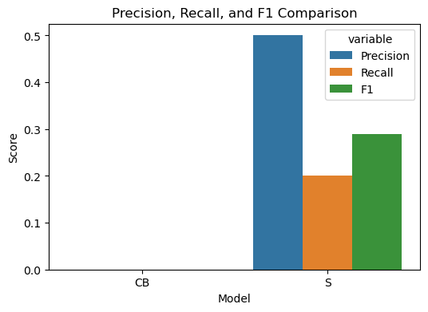

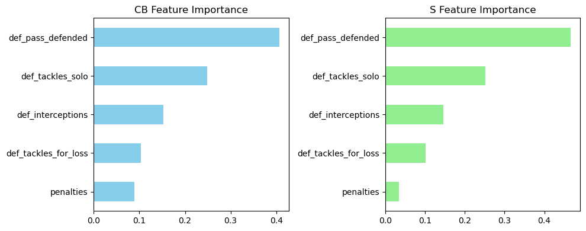

```python
sns.heatmap(confusion_matrix(y_s_test_stats, y_s_pred_stats),
            annot=True, fmt='d', cmap='Greens', ax=axes[1])
axes[1].set_title('S Random Forest Confusion Matrix')
axes[1].set_xlabel('Predicted')
axes[1].set_ylabel('Actual')
plt.tight_layout()
plt.show()


metrics = {
    'Model': ['CB', 'S'],
    'Precision': [0.00, 0.50],
    'Recall': [0.00, 0.20],
    'F1': [0.00, 0.29]
}
plt.figure(figsize=(6,4))
sns.barplot(x='Model', y='value', hue='variable',
            data=pd.melt(pd.DataFrame(metrics), id_vars='Model'))
plt.title('Precision, Recall, and F1 Comparison')
plt.ylabel('Score')
plt.show()


cb_importances = pd.Series(rf_cb_stats.feature_importances_, index=selected_features)
s_importances = pd.Series(rf_s_stats.feature_importances_, index=selected_features)

fig, axes = plt.subplots(1, 2, figsize=(10, 4))
cb_importances.sort_values().plot(kind='barh', ax=axes[0], color='skyblue', title='CB Feature Importance')
s_importances.sort_values().plot(kind='barh', ax=axes[1], color='lightgreen', title='S Feature Importance')
plt.tight_layout()
plt.show()
```

[output not shown]

[output not shown]

These graphs here show us how important each feature is when deciding an All pro, the Feature Importance plots here are showing us that passes defended is the most influential when determining what an All pro defensive back is. This indicates for us contrary to popular belief that constantly being around the ball and disrupting passing plays is more indicative of an all pro defensive back and not just splash plays like interceptions.

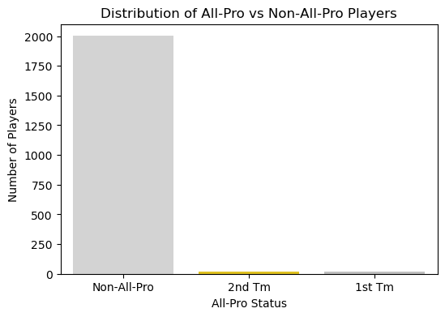

```python
db_combined['ap_designation'] = db_combined['ap_designation'].fillna('Non‑All‑Pro')

plt.figure(figsize=(6,4))
sns.countplot(x='ap_designation', data=db_combined, palette=['lightgray', 'gold', 'silver'])
plt.title('Distribution of All‑Pro vs Non‑All‑Pro Players')
plt.xlabel('All‑Pro Status')
plt.ylabel('Number of Players')
plt.show()
```

This shows the sheer scale of what our model is trying to achieve with how little all pros there are compared to Non all pro dbs, its like trying to find a needle in a haystack